# Tugas Pertemuan 2 - Regresi Deret Waktu dan Penanganan Autokorelasi

Nabeel Muhammad Diaz | M0401241069

# Pemanggilan *Packages*

```r
library(lmtest)   #uji formal pendeteksian autokorelasi (Durbin-Watson)
library(orcutt)   #model regresi Cochrane-Orcutt
library(HoRM)     #model regresi Hildreth-Lu
```

Fungsi Hildreth-Lu didefinisikan sekali di awal agar dapat dipakai pada kedua data.

```r
hildreth.lu.func <- function(r, model){
  x <- model.matrix(model)[,-1]
  y <- model.response(model.frame(model))
  n <- length(y)
  t <- 2:n
  y <- y[t]-r*y[t-1]
  x <- x[t]-r*x[t-1]
  return(lm(y~x))
}
```

# Data 1: Market Share dan Price

## Input Data

Data pertama terdiri atas 20 periode pengamatan dengan peubah *market share* sebagai peubah respon dan *price* sebagai peubah penjelas.

```r
period <- 1:20
marketshare <- c(3.63,4.20,3.33,4.54,2.89,4.87,4.90,5.29,6.18,7.20,
                 7.25,6.09,6.80,8.65,8.43,8.29,7.18,7.90,8.45,8.23)
price <- c(0.97,0.95,0.99,0.91,0.98,0.90,0.89,0.86,0.85,0.82,
           0.79,0.83,0.81,0.77,0.76,0.80,0.83,0.79,0.76,0.78)
data1 <- data.frame(period, marketshare, price)
data1
```

```
##    period marketshare price
## 1       1        3.63  0.97
## 2       2        4.20  0.95
## 3       3        3.33  0.99
## 4       4        4.54  0.91
## 5       5        2.89  0.98
## 6       6        4.87  0.90
## 7       7        4.90  0.89
## 8       8        5.29  0.86
## 9       9        6.18  0.85
## 10     10        7.20  0.82
## 11     11        7.25  0.79
## 12     12        6.09  0.83
## 13     13        6.80  0.81
## 14     14        8.65  0.77
## 15     15        8.43  0.76
## 16     16        8.29  0.80
## 17     17        7.18  0.83
## 18     18        7.90  0.79
## 19     19        8.45  0.76
## 20     20        8.23  0.78
```

## Eksplorasi Data

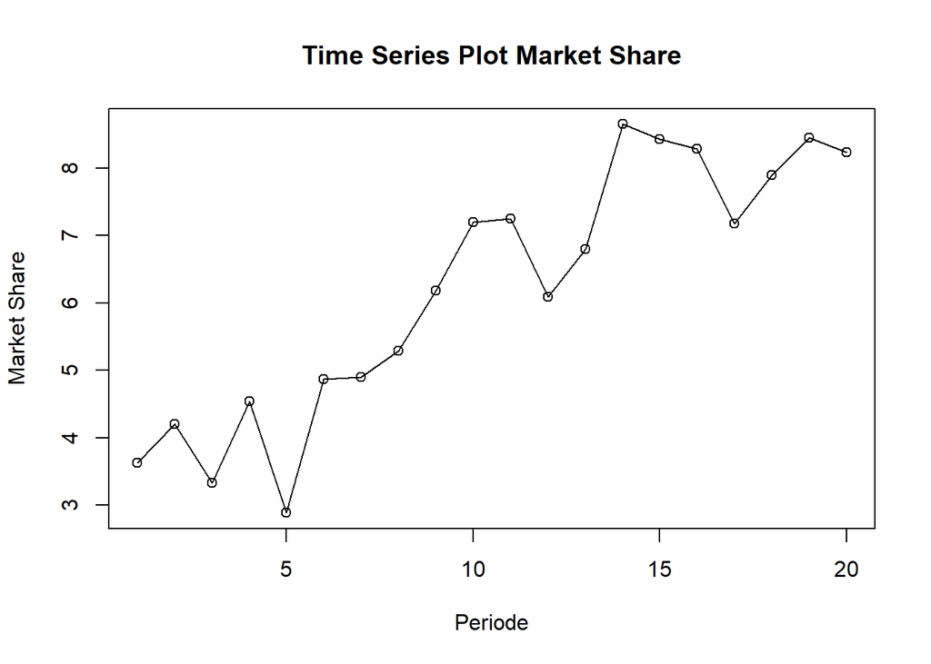

```r
data1.ts <- ts(data1$marketshare)
ts.plot(data1.ts, xlab = "Periode", ylab = "Market Share",
        main = "Time Series Plot Market Share")
points(data1.ts)
```

Plot deret waktu menunjukkan *market share* cenderung meningkat sepanjang periode pengamatan, sehingga terdapat indikasi *trend* naik.

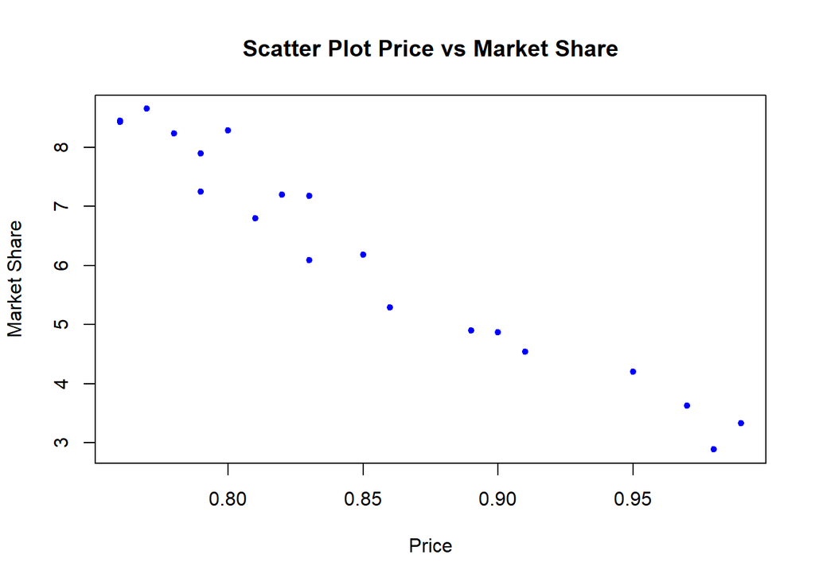

```r
plot(price, marketshare, pch = 20, col = "blue",
     main = "Scatter Plot Price vs Market Share",
     xlab = "Price", ylab = "Market Share")
```

```r
cor(price, marketshare)
```

```
## [1] -0.9752564
```

*Scatter plot* memperlihatkan hubungan **negatif** yang sangat kuat antara *price* dan *market share*, yaitu titik-titik menurun ke arah kanan bawah. Hal ini diperkuat nilai korelasi sebesar $-0.9752564$. Artinya, semakin tinggi harga, semakin rendah pangsa pasar yang diperoleh.

## Model Regresi

```r
model1 <- lm(marketshare ~ price, data = data1)
summary(model1)
```

```
##
## Call:
## lm(formula = marketshare ~ price, data = data1)
##
## Residuals:
##      Min       1Q   Median       3Q      Max
## -0.73068 -0.29764 -0.00966  0.30224  0.81193
##
## Coefficients:
##             Estimate Std. Error t value Pr(>|t|)
## (Intercept)   26.910      1.110   24.25 3.39e-15 ***
## price        -24.290      1.298  -18.72 3.02e-13 ***
## ---
## Signif. codes:  0 '***' 0.001 '**' 0.01 '*' 0.05 '.' 0.1 ' ' 1
##
## Residual standard error: 0.4287 on 18 degrees of freedom
## Multiple R-squared:  0.9511, Adjusted R-squared:  0.9484
## F-statistic: 350.3 on 1 and 18 DF,  p-value: 3.019e-13
```

Model yang dihasilkan adalah
$$\hat{y}_i =
26.910 - 24.290x_t$$

Hasil uji F memiliki *p-value* sebesar $3.019 \times 10^{-13} < \alpha$ (5%), artinya peubah *price* berpengaruh nyata terhadap model. Uji-t parsial pada intersep (*p-value* $= 3.39 \times 10^{-15}$) dan koefisien regresi (*p-value* $= 3.02 \times 10^{-13}$) juga nyata pada taraf 5%. Nilai $R^2 = 0.9511$ berarti 95.11% keragaman *market share* dapat dijelaskan oleh peubah *price*. Meskipun hasilnya terlihat sangat baik, asumsi sisaan tetap perlu diperiksa.

## Uji Asumsi Sisaan

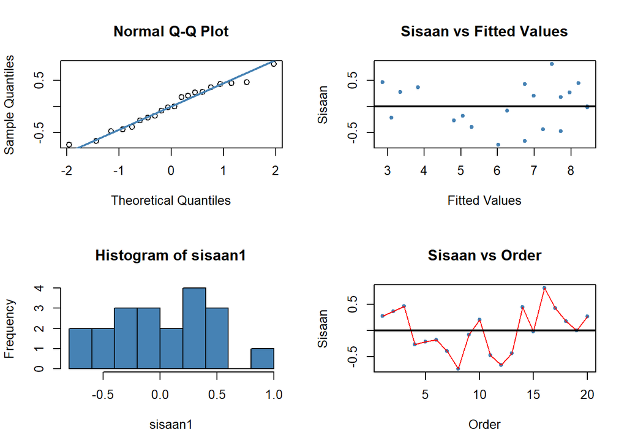

```r
sisaan1 <- residuals(model1)
fitValue1 <- predict(model1)

par(mfrow = c(2,2))
qqnorm(sisaan1)
qqline(sisaan1, col = "steelblue", lwd = 2)
plot(fitValue1, sisaan1, col = "steelblue", pch = 20,
     xlab = "Fitted Values", ylab = "Sisaan", main = "Sisaan vs Fitted Values")
abline(a = 0, b = 0, lwd = 2)
hist(sisaan1, col = "steelblue")
plot(period, sisaan1, col = "steelblue", pch = 20,
     xlab = "Order", ylab = "Sisaan", main = "Sisaan vs Order")
lines(period, sisaan1, col = "red")
abline(a = 0, b = 0, lwd = 2)
```

Normal Q-Q Plot menunjukkan sisaan cenderung mengikuti garis kenormalan. Plot Sisaan vs *Order* memperlihatkan sisaan yang berdekatan cenderung memiliki tanda yang sama (mengelompok positif lalu negatif), yang merupakan indikasi awal adanya autokorelasi.

```r
#H0: sisaan mengikuti sebaran normal
#H1: sisaan tidak mengikuti sebaran normal
shapiro.test(sisaan1)
```

```
##
##  Shapiro-Wilk normality test
##
## data:  sisaan1
## W = 0.9744, p-value = 0.8437
```

```r
ks.test(sisaan1, "pnorm", mean = mean(sisaan1), sd = sd(sisaan1))
```

```
##
##  Exact one-sample Kolmogorov-Smirnov test
##
## data:  sisaan1
## D = 0.11606, p-value = 0.9222
## alternative hypothesis: two-sided
```

Uji Shapiro-Wilk (*p-value* $= 0.8437$) dan Kolmogorov-Smirnov (*p-value* $= 0.9222$) keduanya menghasilkan *p-value* $> \alpha$ (5%). Artinya, tak tolak $H_0$, sisaan menyebar normal sehingga asumsi kenormalan terpenuhi.

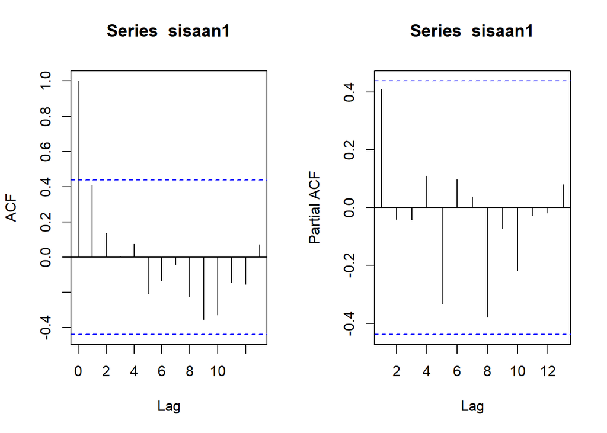

```r
par(mfrow = c(1,2))
acf(sisaan1)
pacf(sisaan1)
```

Berdasarkan plot ACF dan PACF, tidak terdapat *lag* yang keluar dari batas signifikansi $\pm 1.96/\sqrt{20} = \pm 0.4383$. Autokorelasi pada *lag* 1 sebesar $0.4094$ sudah mendekati batas namun belum melewatinya. Karena hasil eksplorasi ini belum konklusif, dilakukan uji formal Durbin-Watson.

## Uji Durbin-Watson

```r
#H0: tidak ada autokorelasi
#H1: ada autokorelasi
dwtest(model1)
```

```
##
##  Durbin-Watson test
##
## data:  model1
## DW = 1.1358, p-value = 0.009813
## alternative hypothesis: true autocorrelation is greater than 0
```

Diperoleh nilai $DW = 1.1358$ dengan *p-value* $= 0.009813$. Berdasarkan tabel Durbin-Watson untuk $n = 20$ dan $k = 1$ pada taraf 5%, diperoleh $DL = 1.2015$ dan $DU = 1.4107$. Nilai $DW = 1.1358 < DL = 1.2015$, sehingga berada pada daerah **autokorelasi positif**. Hal ini didukung *p-value* $= 0.009813 < \alpha$ (5%), artinya tolak $H_0$, cukup bukti menyatakan terdapat autokorelasi pada sisaan. Oleh karena itu diperlukan penanganan autokorelasi.

## Penanganan Autokorelasi

### Metode Cochrane-Orcutt

```r
modelCO1 <- cochrane.orcutt(model1)
modelCO1
```

```
## Cochrane-orcutt estimation for first order autocorrelation
##
## Call:
## lm(formula = marketshare ~ price, data = data1)
##
##  number of interaction: 8
##  rho 0.425232
##
## Durbin-Watson statistic
## (original):    1.13582 , p-value: 9.813e-03
## (transformed): 1.95804 , p-value: 4.151e-01
##
##  coefficients:
## (Intercept)       price
##    26.72209   -24.08413
```

Model setelah penanganan Cochrane-Orcutt adalah
$$\hat{y}_i = 26.72209 - 24.08413x_t$$

Nilai DW meningkat dari $1.13582$ menjadi $1.95804$ dengan *p-value* naik dari $0.009813$ menjadi $0.4151$. Nilai DW sudah berada pada rentang $DU < DW < 4-DU$ atau $1.4107 < 1.95804 < 2.5893$, dan *p-value* $> \alpha$ (5%) sehingga tak tolak $H_0$. Artinya, belum cukup bukti menyatakan adanya autokorelasi setelah penanganan.

```r
rho1 <- modelCO1$rho
rho1
```

```
## [1] 0.4252321
```

Nilai $\hat{\rho}$ optimum yang digunakan adalah $0.425232$.

### Metode Hildreth-Lu

Metode Hildreth-Lu mencari nilai $\rho$ yang meminimumkan SSE melalui *grid search*.

```r
r <- seq(0.1, 0.9, by = 0.1)
tab1 <- data.frame("rho" = r,
                   "SSE" = sapply(r, function(i){deviance(hildreth.lu.func(i, model1))}))
round(tab1, 4)
```

```
##   rho    SSE
## 1 0.1 2.9791
## 2 0.2 2.8105
## 3 0.3 2.7052
## 4 0.4 2.6612
## 5 0.5 2.6749
## 6 0.6 2.7420
## 7 0.7 2.8588
## 8 0.8 3.0265
## 9 0.9 3.2529
```

Terlihat SSE minimum berada di sekitar $\rho = 0.4$. Pencarian diperhalus pada selang 0.3 sampai 0.5 dengan ketelitian 0.001.

```r
rOpt1 <- seq(0.3, 0.5, by = 0.001)
tabOpt1 <- data.frame("rho" = rOpt1,
                      "SSE" = sapply(rOpt1, function(i){deviance(hildreth.lu.func(i, model1))}))
head(tabOpt1[order(tabOpt1$SSE),])
```

```
##       rho      SSE
## 126 0.425 2.659368
## 127 0.426 2.659370
## 125 0.424 2.659372
## 128 0.427 2.659377
## 124 0.423 2.659382
## 129 0.428 2.659390
```

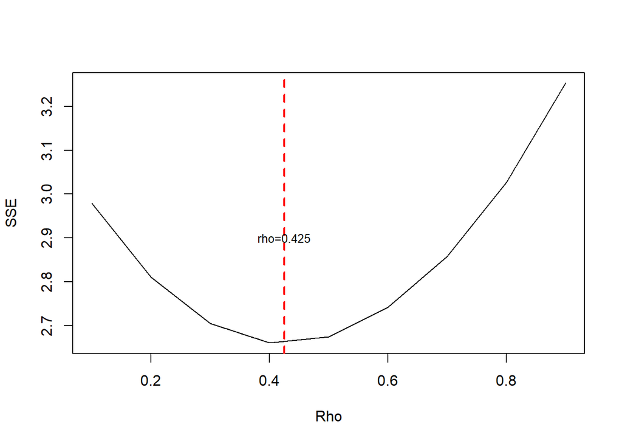

```r
par(mfrow = c(1,1))
plot(tab1$SSE ~ tab1$rho, type = "l", xlab = "Rho", ylab = "SSE")
abline(v = tabOpt1[which.min(tabOpt1$SSE), "rho"], lty = 2, col = "red", lwd = 2)
text(x = 0.425, y = 2.9, labels = "rho=0.425", cex = 0.8)
```

Nilai $\rho$ optimum adalah $0.425$ dengan SSE terkecil sebesar $2.659368$. Nilai ini konsisten dengan $\hat{\rho}$ yang diperoleh metode Cochrane-Orcutt.

```r
modelHL1 <- hildreth.lu.func(0.425, model1)
summary(modelHL1)
```

```
##
## Call:
## lm(formula = y ~ x)
##
## Residuals:
##      Min       1Q   Median       3Q      Max
## -0.55517 -0.25066 -0.05505  0.25010  0.83017
##
## Coefficients:
##             Estimate Std. Error t value Pr(>|t|)
## (Intercept)  15.3655     0.9387   16.37 7.68e-12 ***
## x           -24.0848     1.9380  -12.43 5.88e-10 ***
## ---
## Signif. codes:  0 '***' 0.001 '**' 0.01 '*' 0.05 '.' 0.1 ' ' 1
##
## Residual standard error: 0.3955 on 17 degrees of freedom
## Multiple R-squared:  0.9008, Adjusted R-squared:  0.895
## F-statistic: 154.4 on 1 and 17 DF,  p-value: 5.88e-10
```

```r
#Transformasi balik
b0hl1 <- coef(modelHL1)[1]/(1-0.425)
b1hl1 <- coef(modelHL1)[2]
cat("y = ", b0hl1, ifelse(b1hl1 < 0, " ", " +"), b1hl1, "x", sep = "")
```

```
## y = 26.72268 -24.08484x
```

Setelah transformasi balik, diperoleh model
$$\hat{y}_i = 26.72268 - 24.08484x_t$$
yang praktis identik dengan hasil Cochrane-Orcutt.

```r
dwtest(modelHL1)
```

```
##
##  Durbin-Watson test
##
## data:  modelHL1
## DW = 1.9577, p-value = 0.4148
## alternative hypothesis: true autocorrelation is greater than 0
```

Nilai $DW = 1.9577$ berada pada rentang $1.4107 < DW < 2.5893$ dengan *p-value* $= 0.4148 > \alpha$ (5%). Artinya tak tolak $H_0$, autokorelasi sudah tertangani.

### Perbandingan Model

```r
sseAwal1 <- anova(model1)$`Sum Sq`[-1]
sseHL1 <- anova(modelHL1)$`Sum Sq`[-1]
mseAwal1 <- sseAwal1/length(marketshare)
mseHL1 <- sseHL1/length(marketshare)
akurasi1 <- matrix(c(sseAwal1, sseHL1, mseAwal1, mseHL1), nrow = 2, byrow = TRUE)
colnames(akurasi1) <- c("Model Awal", "Model Hildreth-Lu")
row.names(akurasi1) <- c("SSE", "MSE")
akurasi1
```

```
##     Model Awal Model Hildreth-Lu
## SSE  3.3082574         2.6593683
## MSE  0.1654129         0.1329684
```

SSE turun dari $3.308257$ pada model awal menjadi $2.659368$ setelah penanganan, menunjukkan model hasil penanganan lebih baik.

# Data 2: Sales dan Advertising

## Input Data

Data kedua merupakan data tahunan periode 1975-2014 dengan *sales* sebagai peubah respon dan *advertising* sebagai peubah penjelas.

```r
year <- 1975:2014
sales <- c(11.7,12.0,12.3,12.8,13.1,13.6,13.9,14.4,14.7,15.3,
           15.5,15.8,16.1,16.6,16.9,16.7,16.9,17.4,17.6,17.9,
           18.0,17.9,18.0,18.2,18.2,18.3,18.6,19.2,19.3,19.5,
           19.2,19.3,19.5,20.0,20.0,19.9,19.8,19.9,20.2,21.0)
advertising <- c(9.4,9.6,10.0,10.4,10.8,10.9,11.7,12.2,12.5,12.9,
                 13.0,13.2,13.8,14.2,14.6,14.4,15.0,15.4,15.7,15.9,
                 15.9,16.0,16.3,16.2,16.8,17.3,17.6,18.1,18.3,18.5,
                 18.7,18.9,19.2,20.0,20.0,20.3,20.4,21.0,21.5,22.1)
data2 <- data.frame(year, sales, advertising)
data2
```

```
##    year sales advertising
## 1  1975  11.7         9.4
## 2  1976  12.0         9.6
## 3  1977  12.3        10.0
## 4  1978  12.8        10.4
## 5  1979  13.1        10.8
## 6  1980  13.6        10.9
## 7  1981  13.9        11.7
## 8  1982  14.4        12.2
## 9  1983  14.7        12.5
## 10 1984  15.3        12.9
## 11 1985  15.5        13.0
## 12 1986  15.8        13.2
## 13 1987  16.1        13.8
## 14 1988  16.6        14.2
```

[output cut: 26 more lines]

## Eksplorasi Data

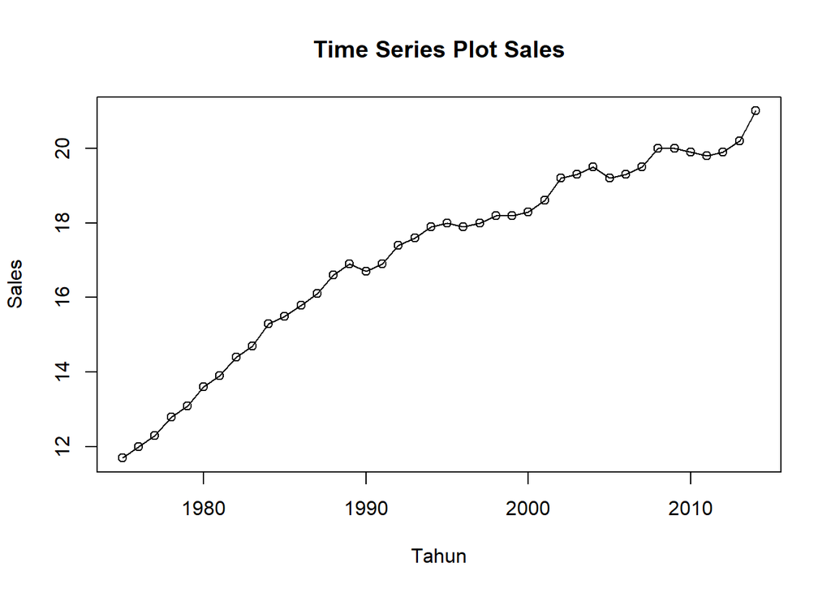

```r
data2.ts <- ts(data2$sales, start = 1975)
ts.plot(data2.ts, xlab = "Tahun", ylab = "Sales", main = "Time Series Plot Sales")
points(data2.ts)
```

Plot deret waktu menunjukkan *trend* naik yang jelas sepanjang tahun 1975-2014.

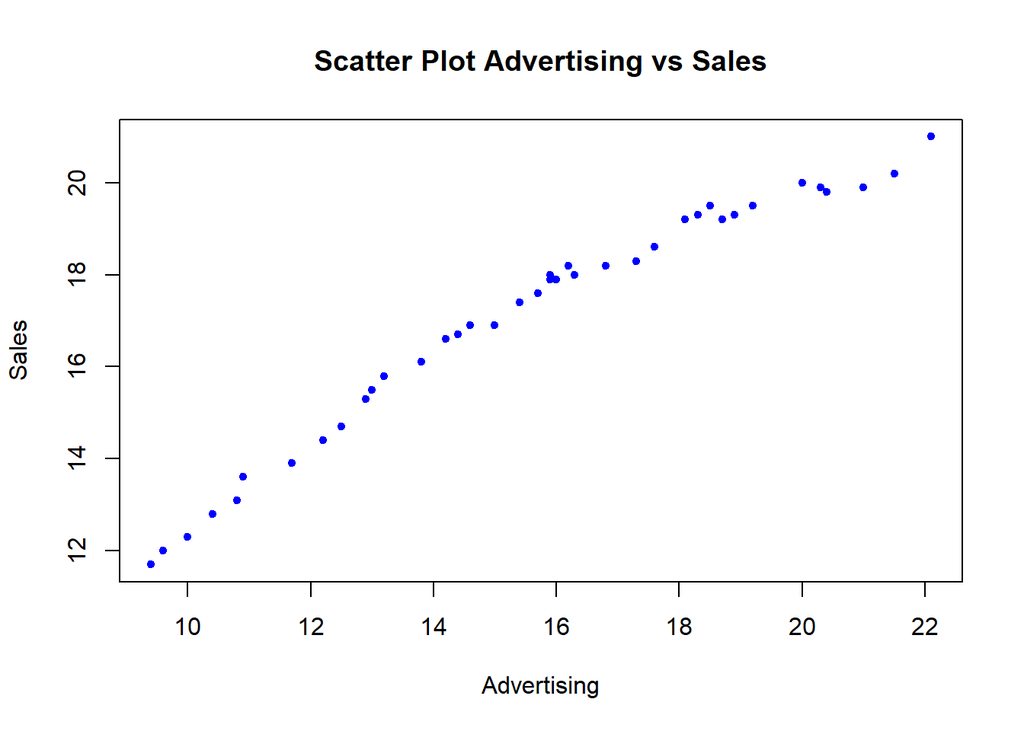

```r
plot(advertising, sales, pch = 20, col = "blue",
     main = "Scatter Plot Advertising vs Sales",
     xlab = "Advertising", ylab = "Sales")
```

```r
cor(advertising, sales)
```

```
## [1] 0.9795849
```

Terdapat hubungan positif yang sangat kuat antara *advertising* dan *sales* dengan nilai korelasi $0.9795849$.

## Model Regresi

```r
model2 <- lm(sales ~ advertising, data = data2)
summary(model2)
```

```
##
## Call:
## lm(formula = sales ~ advertising, data = data2)
##
## Residuals:
##      Min       1Q   Median       3Q      Max
## -1.03758 -0.40343  0.08933  0.45674  0.74036
##
## Coefficients:
##             Estimate Std. Error t value Pr(>|t|)
## (Intercept)  5.96513    0.38092   15.66   <2e-16 ***
## advertising  0.71035    0.02365   30.04   <2e-16 ***
## ---
## Signif. codes:  0 '***' 0.001 '**' 0.01 '*' 0.05 '.' 0.1 ' ' 1
##
## Residual standard error: 0.527 on 38 degrees of freedom
## Multiple R-squared:  0.9596, Adjusted R-squared:  0.9585
## F-statistic: 902.3 on 1 and 38 DF,  p-value: < 2.2e-16
```

Model yang dihasilkan adalah
$$\hat{y}_i =
5.96513 + 0.71035x_t$$

Uji F menghasilkan *p-value* $< 2.2 \times 10^{-16} < \alpha$ (5%), demikian pula uji-t pada kedua parameter. Nilai $R^2 = 0.9596$ berarti 95.96% keragaman *sales* dijelaskan oleh *advertising*.

## Uji Asumsi Sisaan

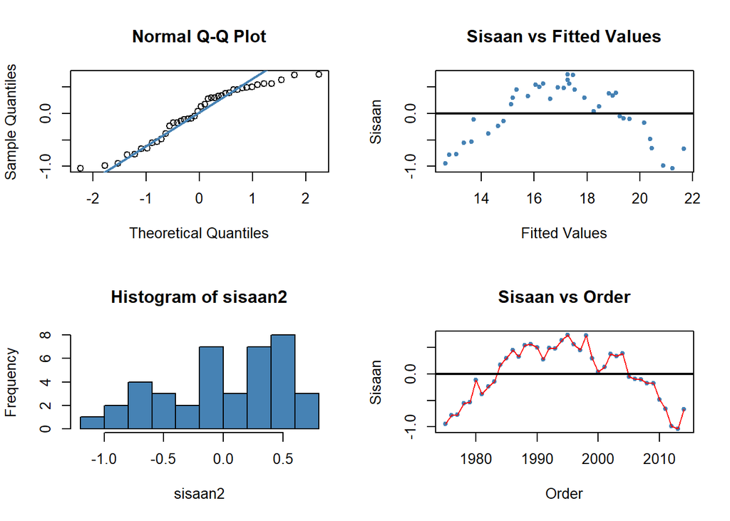

```r
sisaan2 <- residuals(model2)
fitValue2 <- predict(model2)

par(mfrow = c(2,2))
qqnorm(sisaan2)
qqline(sisaan2, col = "steelblue", lwd = 2)
plot(fitValue2, sisaan2, col = "steelblue", pch = 20,
     xlab = "Fitted Values", ylab = "Sisaan", main = "Sisaan vs Fitted Values")
abline(a = 0, b = 0, lwd = 2)
hist(sisaan2, col = "steelblue")
plot(year, sisaan2, col = "steelblue", pch = 20,
     xlab = "Order", ylab = "Sisaan", main = "Sisaan vs Order")
lines(year, sisaan2, col = "red")
abline(a = 0, b = 0, lwd = 2)
```

Plot Sisaan vs *Order* menunjukkan pola gelombang yang sangat jelas, di mana sisaan bertahan lama pada nilai positif kemudian berpindah ke nilai negatif. Pola ini merupakan ciri kuat adanya autokorelasi positif.

```r
shapiro.test(sisaan2)
```

```
##
##  Shapiro-Wilk normality test
##
## data:  sisaan2
## W = 0.93205, p-value = 0.0188
```

```r
ks.test(sisaan2, "pnorm", mean = mean(sisaan2), sd = sd(sisaan2))
```

```
##
##  Asymptotic one-sample Kolmogorov-Smirnov test
##
## data:  sisaan2
## D = 0.15458, p-value = 0.2948
## alternative hypothesis: two-sided
```

Kedua uji memberikan kesimpulan yang berbeda. Uji Shapiro-Wilk menghasilkan *p-value* $= 0.0188 < \alpha$ (5%) sehingga tolak $H_0$, sedangkan uji Kolmogorov-Smirnov menghasilkan *p-value* $= 0.2948 > \alpha$ (5%) sehingga tak tolak $H_0$. Histogram sisaan yang terlihat cenderung datar mendukung hasil Shapiro-Wilk, sehingga asumsi kenormalan pada data ini kurang terpenuhi. Namun, penyimpangan kenormalan ini sebagian besar disebabkan oleh autokorelasi yang kuat, sehingga penanganan autokorelasi tetap menjadi prioritas.

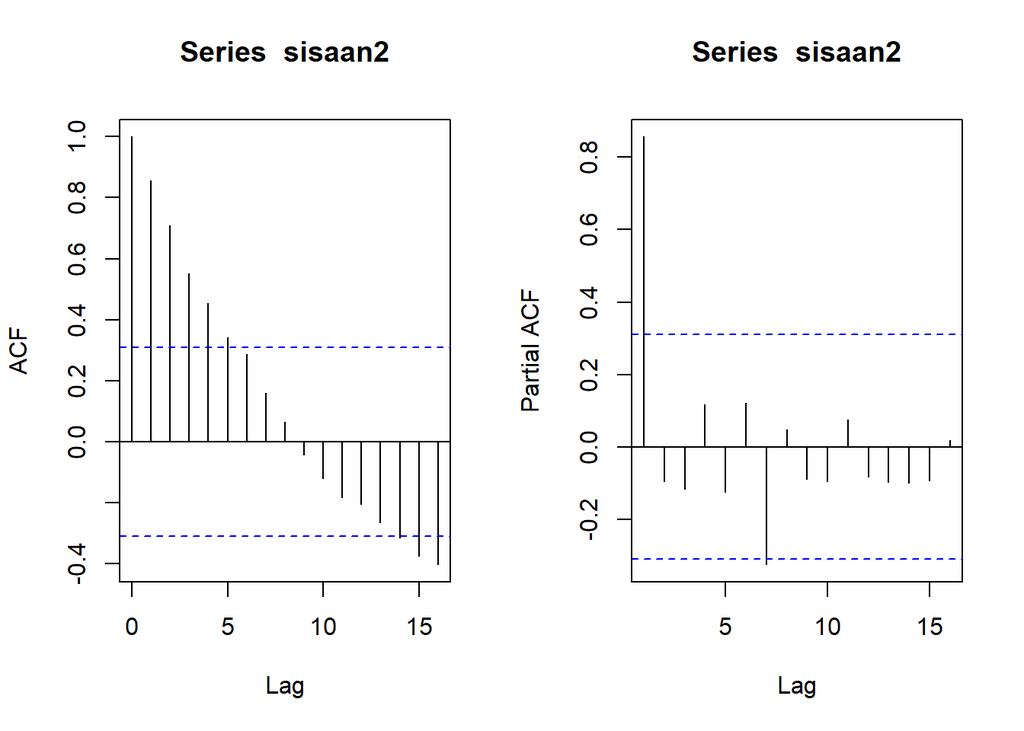

```r
par(mfrow = c(1,2))
acf(sisaan2)
pacf(sisaan2)
```

## Uji Durbin-Watson

```r
dwtest(model2)
```

```
##
##  Durbin-Watson test
##
## data:  model2
## DW = 0.16204, p-value < 2.2e-16
## alternative hypothesis: true autocorrelation is greater than 0
```

Diperoleh $DW = 0.16204$ dengan *p-value* $< 2.2 \times 10^{-16}$. Berdasarkan tabel Durbin-Watson untuk $n = 40$ dan $k = 1$ pada taraf 5%, diperoleh $DL = 1.4421$ dan $DU = 1.5440$. Nilai $DW = 0.16204$ jauh lebih kecil daripada $DL$, sehingga berada pada daerah **autokorelasi positif** yang sangat kuat. Tolak $H_0$, terdapat autokorelasi pada sisaan sehingga perlu dilakukan penanganan.

## Penanganan Autokorelasi

### Metode Cochrane-Orcutt

```r
modelCO2 <- cochrane.orcutt(model2)
modelCO2
```

```
## Cochrane-orcutt estimation for first order autocorrelation
##
## Call:
## lm(formula = sales ~ advertising, data = data2)
##
##  number of interaction: 39
##  rho 0.903123
##
## Durbin-Watson statistic
## (original):    0.16204 , p-value: 8.935e-20
## (transformed): 1.93925 , p-value: 3.78e-01
##
##  coefficients:
## (Intercept) advertising
##   10.252375    0.488489
```

Model setelah penanganan adalah
$$\hat{y}_i = 10.252375 + 0.488489x_t$$

Nilai DW meningkat drastis dari $0.16204$ menjadi $1.93925$ dengan *p-value* naik menjadi $0.378$. Nilai DW berada pada rentang $DU < DW < 4-DU$ atau $1.5440 < 1.93925 < 2.4560$ dan *p-value* $> \alpha$ (5%), sehingga tak tolak $H_0$. Autokorelasi sudah tertangani.

```r
rho2 <- modelCO2$rho
rho2
```

```
## [1] 0.9031233
```

Nilai $\hat{\rho}$ optimum sebesar $0.903123$, jauh lebih besar dibandingkan data pertama, sejalan dengan autokorelasi yang jauh lebih kuat pada data ini.

### Metode Hildreth-Lu

```r
r <- seq(0.1, 0.9, by = 0.1)
tab2 <- data.frame("rho" = r,
                   "SSE" = sapply(r, function(i){deviance(hildreth.lu.func(i, model2))}))
round(tab2, 4)
```

```
##   rho    SSE
## 1 0.1 7.8457
## 2 0.2 6.3303
## 3 0.3 5.0154
## 4 0.4 3.9007
## 5 0.5 2.9856
## 6 0.6 2.2692
## 7 0.7 1.7494
## 8 0.8 1.4226
## 9 0.9 1.2914
```

SSE masih terus menurun sampai ujung selang $\rho = 0.9$, sehingga pencarian diperluas dan diperhalus pada selang 0.8 sampai 0.99 dengan ketelitian 0.001.

```r
rOpt2 <- seq(0.8, 0.99, by = 0.001)
tabOpt2 <- data.frame("rho" = rOpt2,
                      "SSE" = sapply(rOpt2, function(i){deviance(hildreth.lu.func(i, model2))}))
head(tabOpt2[order(tabOpt2$SSE),])
```

```
##       rho      SSE
## 104 0.903 1.291226
## 105 0.904 1.291239
## 103 0.902 1.291248
## 106 0.905 1.291289
## 102 0.901 1.291304
## 107 0.906 1.291375
```

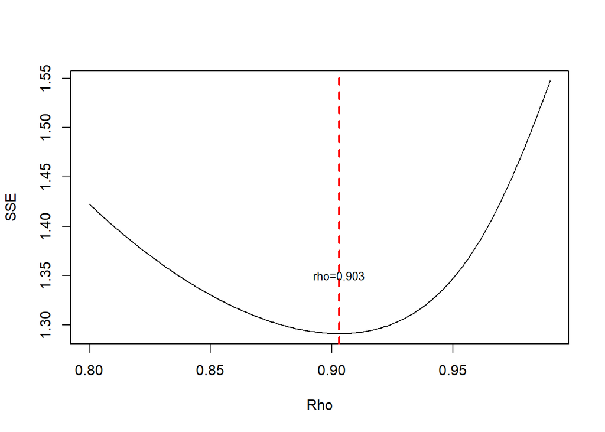

```r
par(mfrow = c(1,1))
plot(tabOpt2$SSE ~ tabOpt2$rho, type = "l", xlab = "Rho", ylab = "SSE")
abline(v = tabOpt2[which.min(tabOpt2$SSE), "rho"], lty = 2, col = "red", lwd = 2)
text(x = 0.903, y = 1.35, labels = "rho=0.903", cex = 0.8)
```

Nilai $\rho$ optimum adalah $0.903$ dengan SSE terkecil $1.291226$, konsisten dengan hasil Cochrane-Orcutt.

```r
modelHL2 <- hildreth.lu.func(0.903, model2)
summary(modelHL2)
```

```
##
## Call:
## lm(formula = y ~ x)
##
## Residuals:
##      Min       1Q   Median       3Q      Max
## -0.37720 -0.14949  0.01266  0.10464  0.45301
##
## Coefficients:
##             Estimate Std. Error t value Pr(>|t|)
## (Intercept)  0.99401    0.14144   7.028 2.60e-08 ***
## x            0.48869    0.07536   6.485 1.39e-07 ***
## ---
## Signif. codes:  0 '***' 0.001 '**' 0.01 '*' 0.05 '.' 0.1 ' ' 1
##
## Residual standard error: 0.1868 on 37 degrees of freedom
## Multiple R-squared:  0.532,  Adjusted R-squared:  0.5193
## F-statistic: 42.05 on 1 and 37 DF,  p-value: 1.39e-07
```

```r
#Transformasi balik
b0hl2 <- coef(modelHL2)[1]/(1-0.903)
b1hl2 <- coef(modelHL2)[2]
cat("y = ", b0hl2, ifelse(b1hl2 < 0, " ", " +"), b1hl2, "x", sep = "")
```

```
## y = 10.24749 +0.4886925x
```

Setelah transformasi balik diperoleh model
$$\hat{y}_i = 10.24749 + 0.4886925x_t$$
yang praktis sama dengan hasil Cochrane-Orcutt.

```r
dwtest(modelHL2)
```

```
##
##  Durbin-Watson test
##
## data:  modelHL2
## DW = 1.9393, p-value = 0.378
## alternative hypothesis: true autocorrelation is greater than 0
```

Nilai $DW = 1.9393$ berada pada rentang $1.5440 < DW < 2.4560$ dengan *p-value* $= 0.378 > \alpha$ (5%). Tak tolak $H_0$, autokorelasi sudah tertangani.

### Perbandingan Model

```r
sseAwal2 <- anova(model2)$`Sum Sq`[-1]
sseHL2 <- anova(modelHL2)$`Sum Sq`[-1]
mseAwal2 <- sseAwal2/length(sales)
mseHL2 <- sseHL2/length(sales)
akurasi2 <- matrix(c(sseAwal2, sseHL2, mseAwal2, mseHL2), nrow = 2, byrow = TRUE)
colnames(akurasi2) <- c("Model Awal", "Model Hildreth-Lu")
row.names(akurasi2) <- c("SSE", "MSE")
akurasi2
```

```
##     Model Awal Model Hildreth-Lu
## SSE 10.5545322        1.29122572
## MSE  0.2638633        0.03228064
```

SSE turun sangat tajam dari $10.55453$ menjadi $1.291226$, yaitu berkurang sekitar 87.8%. Penurunan yang jauh lebih besar dibandingkan data pertama ini wajar karena autokorelasi pada data kedua memang jauh lebih kuat.

# Simpulan

Kedua data menghasilkan model regresi dengan $R^2$ yang tinggi, yaitu $0.9511$ untuk data *market share* dan $0.9596$ untuk data *sales*. Namun, keduanya melanggar asumsi kebebasan sisaan.

Pada data pertama, hubungan antara *price* dan *market share* bersifat negatif. Plot ACF dan PACF belum menunjukkan *lag* yang melewati batas signifikansi, tetapi uji formal Durbin-Watson dengan $DW = 1.1358 < DL$ membuktikan adanya autokorelasi positif. Hal ini menegaskan bahwa uji formal tetap diperlukan meskipun hasil eksplorasi terlihat aman.

Pada data kedua, hubungan antara *advertising* dan *sales* bersifat positif dengan autokorelasi yang jauh lebih kuat. Hal ini terlihat dari ACF yang *tails off*, PACF yang *cuts off* pada *lag* 1, serta $DW = 0.16204$ yang sangat jauh di bawah $DL$.

Penanganan dengan metode Cochrane-Orcutt dan Hildreth-Lu menghasilkan nilai $\hat{\rho}$ dan model yang praktis identik pada kedua data, yaitu $\hat{\rho} \approx 0.425$ untuk data pertama dan $\hat{\rho} \approx 0.903$ untuk data kedua. Setelah penanganan, nilai DW pada kedua data masuk ke rentang $DU < DW < 4-DU$ dengan *p-value* $> \alpha$ (5%), disertai penurunan SSE. Dengan demikian, kedua metode sama-sama berhasil menangani autokorelasi.